# Time Series Forecasting

Xiaorui (Jeremy) Zhu

03/15/2026

# Case: Forecasting Apple Revenue 1

Apple Inc. is a global technology company with rapidly changing revenue driven by product launches and market trends.

- In 2020, Apple reported $64.7 billion in quarterly revenue, boosted by strong demand during the COVID-19 pandemic.
- Revenue fluctuates over time due to factors like seasonality, new products, and economic conditions.

# Case: Forecasting Apple Revenue 2

Key Question:

1. How can we use past revenue data to understand patterns and forecast future performance?
2. As an analyst, you will apply time-series models to analyze and predict Apple’s revenue.

```
## # A tibble: 2 × 3
##   Year  Quarter Revenue
##   <chr>   <dbl>   <dbl>
## 1 2010        1   15683
## 2 2010        2   13499
```

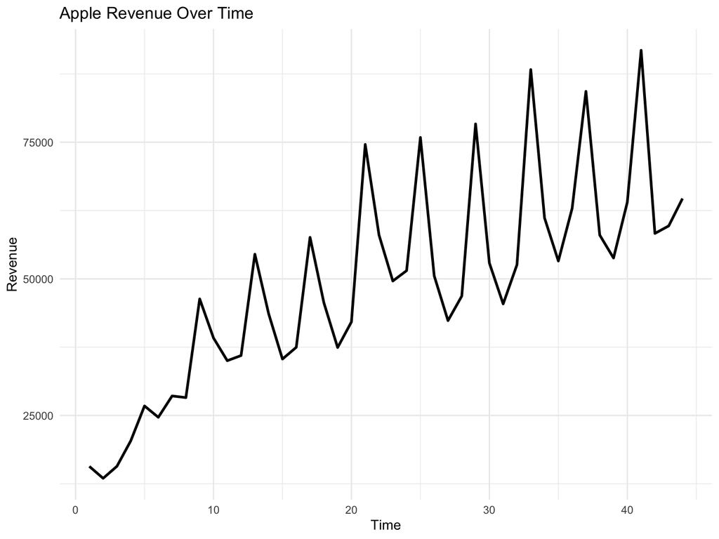

# What is Time-series Data and Forecasting?

- A time series is data collected over time (e.g., quarterly revenue)
- Time periods can be expressed as year, quarter, month, week, day, hour or seconds.
- Goal: use past data to predict future values
- Important for business decisions (planning, budgeting)

# Time-series Data

A time series is characterized by four components:

1. **Trend**: long-term up/down movements
2. **Seasonal**: repetitions over a one-year period, magnitudes of the up/down swings are more predictable
3. **Cyclic**: wavelike fluctuations or business cycles, duration lasts several years and differs from cycle to cycle
4. **Random**: unexplained movements

# Simple Smoothing Methods

## Why Do We Need Smoothing?

- Real-world data fluctuates (noise)
- Hard to see underlying patterns
- Smoothing helps:
  - Reveal trends
  - Improve forecasts

## Moving Average Method

**Idea:** Use the average of the last *n* observations

$$F_{t+1} = \frac{Y_t + Y_{t-1} + ... + Y_{t-n+1}}{n}$$

- Simple and intuitive
- Larger window (n) → smoother but slower to react

## Moving Average Example (R)

```r
library(readxl)
# Load Apple revenue data
data <- read_excel("data/Revenue_Apple.xlsx")
table(data$Year)
```

```
##
## 2010 2011 2012 2013 2014 2015 2016 2017 2018 2019 2020
##    4    4    4    4    4    4    4    4    4    4    4
```

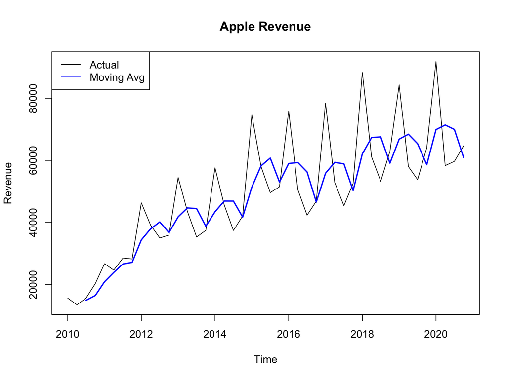

```r
# Example: suppose data starts at 2005 Q1
ts_revenue <- ts(data$Revenue,
              start = c(2010, 1),   # Year, Quarter
              frequency = 4)        # Quarterly data

# Plot raw data
plot(ts_revenue, type="l", main="Apple Revenue", ylab="Revenue")
# Moving average (3-period)
ma <- stats::filter(ts_revenue, rep(1/3, 3), sides=1)
lines(ma, col="blue", lwd=2)
legend("topleft", legend=c("Actual","Moving Avg"), col=c("black","blue"), lty=1)
```

## Simple Exponential Smoothing (SES)

**Idea:** Weighted average of past values

$$F_{t+1} = \alpha Y_t + (1 - \alpha)F_t$$

- $\alpha$ controls how fast the model reacts
- More flexible than moving average

## How Simple Exponential Smoothing (SES) Works

- Instead of averaging equally (like moving average), SES:
  - Gives more importance to recent data
  - Gradually discounts older observations
- Forecast is updated each period using:

$$F_{t+1} = \alpha Y_t + (1 - \alpha)F_t$$

- New forecast = (weight × latest actual) + (remaining weight × previous forecast)

## Exponential Smoothing Example (R)

```r
library(forecast)
```

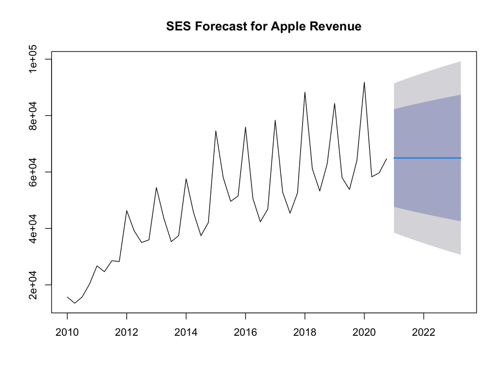

```r
# use the time series date to Fit SES model
ses_model <- ses(ts_revenue)
# Plot
plot(ses_model, main="SES Forecast for Apple Revenue")
```

## Exponential Smoothing Forecasting

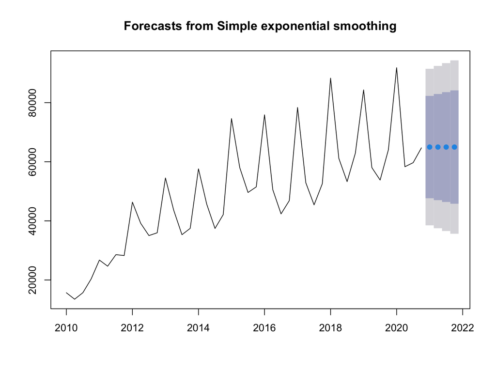

```r
forecast_values <- forecast(ses_model, h=4)
plot(forecast_values)
```

## Autoregressive (AR) Model

**Idea:** Use past values to predict future values

$$Y_t = c + \phi_1 Y_{t-1} + \phi_2 Y_{t-2} + ... + \epsilon_t$$

- Uses correlation in time series
- More advanced than smoothing

## AR Model Example (R)

```r
# Step 1: Split the training and testing sets
train <- window(ts_revenue, end = c(2018,4))   # adjust
test  <- window(ts_revenue, start = c(2019,1))

# Step 2: Fit model on training
library(forecast)
model <- Arima(train, order = c(1,0,0))
fc <- forecast(model, h = length(test))

# Step 3: Evaluate accuracy
accuracy(fc, test)
```

```
##                      ME     RMSE      MAE       MPE     MAPE     MASE
## Training set   679.4677 13978.84 10625.47 -9.716929 26.42132 1.422253
## Test set     18441.6402 22187.97 18441.64 25.495862 25.49586 2.468471
##                     ACF1 Theil's U
## Training set -0.06179602        NA
## Test set     -0.09528257   1.30426
```

## Optional Visualization

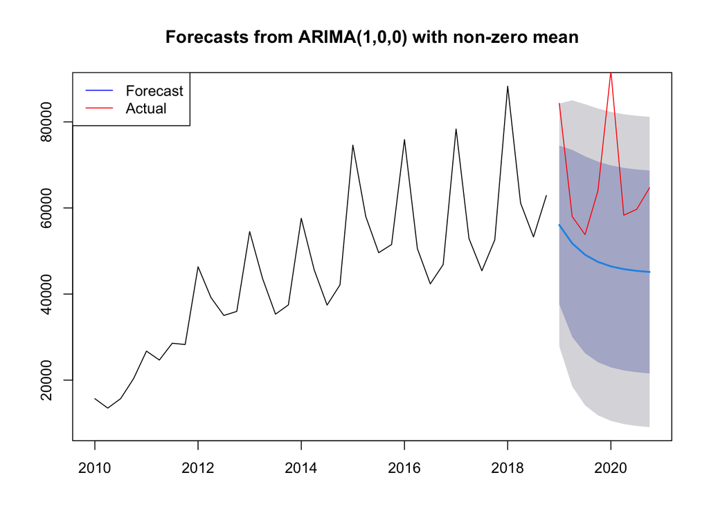

```r
plot(fc)
lines(test, col="red")
legend("topleft",
       legend=c("Forecast","Actual"),
       col=c("blue","red"),
       lty=1)
```

## Better Model and Visualization

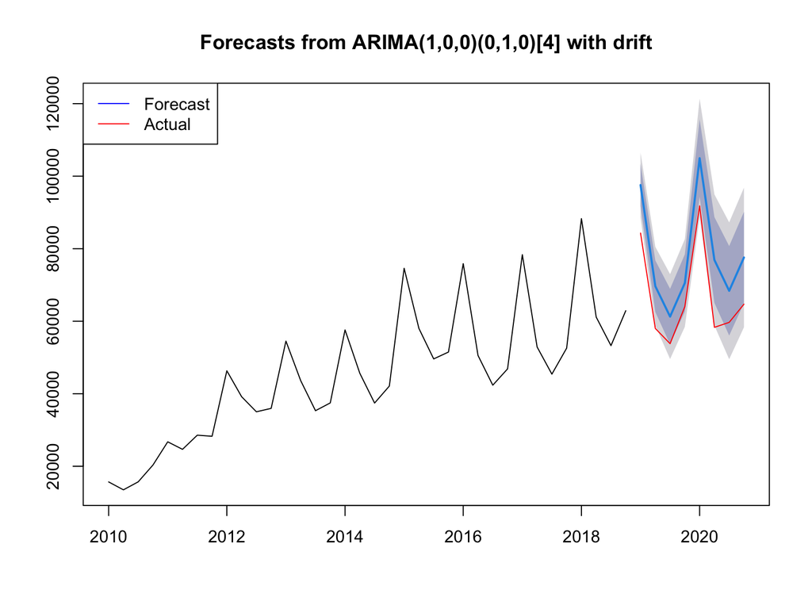

```r
# Better model
model2 <- auto.arima(train)
fc2 <- forecast(model2, h = length(test))
# Visualization
plot(fc2)
lines(test, col="red")
legend("topleft",
       legend=c("Forecast","Actual"),
       col=c("blue","red"),
       lty=1)
```

## Key Takeaways

- Moving Average: simple and stable
- Exponential Smoothing: more flexible
- AR Model: uses time dependence
- Start simple, then move to more advanced models